# A U-method report: evaluating marker stability in small single-cell populations

Yaniv Stein

2026-06-03

# 1 Motivation

Cellular heterogeneity in small single-cell datasets suffers from unstable expression averages that lead to semi-arbitrary ranking, favoring high expression magnitude over stable canonical markers. The question of the exercise is: Can an expression probability framework anchor these genes compared to each other, preserving their high ranking under sampling pressure?

# 2 Data processing

Primary liver samples from five patients were profiled using 10X Genomics single-cell RNA sequencing.

Data were downloaded from GEO:

https://www.ncbi.nlm.nih.gov/geo/query/acc.cgi?acc=GSE115469

The goal is to evaluate whether expression polarization provides a stable basis for marker identification and cluster annotation in small cell populations.

```r
library(harmony)
library(Umethod)
library(cowplot)
library(ggplot2)
library(Seurat)
library(RColorBrewer)
library(presto) # Tried it without presto, same results x30 time slower

dir <- "./Data/GSE115469_Data.csv"
liver.data <- read.csv(dir, row.names = 1)

sample <- sapply(strsplit(colnames(liver.data),split = "_"),function(x){x[1][1]})
seurat <- CreateSeuratObject(liver.data[,which(sample == unique(sample)[1])],project = unique(sample)[1])
for(i in unique(sample)[-1]){
  tmp <-  CreateSeuratObject(liver.data[,which(sample == i)],project = i)
  seurat <- merge(seurat,tmp)
}

seurat[["percent.mt"]] <- PercentageFeatureSet(seurat, pattern = "^MT-|^MT-[.]|^MT[.]|^MTRNR")
#VlnPlot(seurat, features = c("nFeature_RNA", "nCount_RNA", "percent.mt"),group.by = "orig.ident",pt.size = 0)

seurat <- subset(seurat, subset = nFeature_RNA > 200 & nFeature_RNA < 10000 & percent.mt < 20) # already filtered
seurat <- JoinLayers(seurat)
seurat <- NormalizeData(seurat, normalization.method = "LogNormalize", scale.factor = 10000)
seurat <- FindVariableFeatures(seurat, selection.method = "vst", nfeatures = 2000)
seurat <- ScaleData(object = seurat)
seurat <- RunPCA(object = seurat, npcs=20)
seurat_harmonized <-RunHarmony(seurat,"orig.ident")
seurat_harmonized<- RunUMAP(seurat_harmonized, reduction = "harmony", dims = 1:20,reduction.name = "UMAP_on_harmony", seed.use = 1234)
seurat_harmonized<- FindNeighbors(seurat_harmonized, reduction = "harmony", dims = 1:20)
seurat_harmonized <- FindClusters(seurat_harmonized, graph.name = "RNA_snn", resolution = .05 , algorithm = 1)
```

# 3 Cluster annotation using the U-method

Cells were integrated across patients using Harmony and clustered in a shared low-dimensional space. Cluster identities were assigned using marker genes identified by the U-method. The resulting populations corresponded to major liver cell types, including hepatocytes, cholangiocytes, myeloid cells, lymphocytes, plasma cells, endothelial cells, erythroid cells, and fibroblasts/pericytes.

```r
(UmethodResults <- FindUniqueMarkers(
  obj = seurat_harmonized,
  group_by = "RNA_snn_res.0.05",
  n = 5
))$gene_set
```

```
##      0          1      2          3          4          5           6
## [1,] "CPS1"     "CCL5" "AIF1"     "PTPRB"    "MZB1"     "MS4A1"     "FXYD2"
## [2,] "HSD17B6"  "GZMA" "CD163"    "EGFL7"    "TNFRSF17" "LTB"       "SPP1"
## [3,] "PLG"      "NKG7" "LST1"     "CCL14"    "JCHAIN"   "CD79A"     "ANXA4"
## [4,] "APOA5"    "CD7"  "S100A9"   "RAMP3"    "PIM2"     "LINC00926" "KRT7"
## [5,] "SERPINC1" "CST7" "C1orf162" "DNASE1L3" "DERL3"    "CD52"      "LGALS4"
##      7       8
## [1,] "CA1"   "DCN"
## [2,] "AHSP"  "MYL9"
## [3,] "HBD"   "COL1A2"
## [4,] "ALAS2" "ACTA2"
## [5,] "SNCA"  "COL3A1"
```

I reordered the cluster factor levels to group biologically related cell types together, ensuring intuitive layout alignment.

```r
# Assign biological identities to clusters
celltypes <- c(
  "Hepatocytes",
  "T/NK cells",
  "Myeloid cells",
  "Endothelial cells",
  "Plasma cells",
  "B cells",
  "Cholangiocytes",
  "Erythroid cells",
  "Fibroblasts/Pericytes"
)

seurat_harmonized$Celltype <- seurat_harmonized$RNA_snn_res.0.05
levels(seurat_harmonized$Celltype) <- celltypes
seurat_harmonized$Celltype <- ordered(seurat_harmonized$Celltype,celltypes[c(1,7,3,2,6,5,8,4,9)])

table(seurat_harmonized$Celltype)
```

```
##
##           Hepatocytes        Cholangiocytes         Myeloid cells
##                  3520                   116                  1199
##            T/NK cells               B cells          Plasma cells
##                  2030                   127                   497
##       Erythroid cells     Endothelial cells Fibroblasts/Pericytes
##                    95                   813                    42
```

The dataset contained 3,520 hepatocytes, 2,030 T/NK cells, 1,199 myeloid cells, 813 endothelial cells, 497 plasma cells, 127 B cells, 116 cholangiocytes, 95 erythroid cells, and 42 fibroblast/pericyte cells.

```r
U_time <- system.time({
  UmethodResults <- FindUniqueMarkers(
    obj = seurat_harmonized,
    group_by = "Celltype",
    Uscore = 0.2,
    n = 5
  )
})

cat("U-method calculation time:", unname(U_time["elapsed"]), "seconds\n")
```

```
## U-method calculation time: 1.19 seconds
```

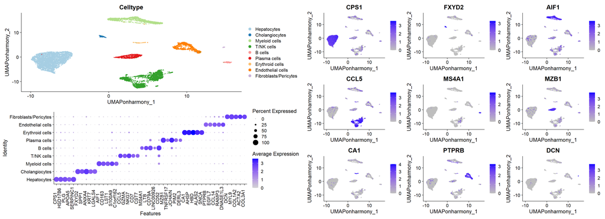

```r
Liver_gg<- plot_grid(
  plot_grid(
    DimPlot(object = seurat_harmonized, reduction = "UMAP_on_harmony", pt.size = 0.5, group.by = "Celltype")+ scale_color_manual(values =  brewer.pal(n = 9, name = "Paired")),
    DotPlot(seurat_harmonized, features = c(UmethodResults$gene_set), group.by = "Celltype", scale = FALSE) +
      theme(axis.text.x = element_text(angle = 90, vjust = -0.0001)),
    ncol = 1
  ),
  FeaturePlot(
    object = seurat_harmonized,
    features = UmethodResults$gene_set[1, ],
    cols = c("gray", "blue"),
    reduction = "UMAP_on_harmony",
    ncol = 3,
    order = TRUE
  ),
  ncol = 2
)

Liver_gg
```

# 4 Marker identification using differential expression

Differential expression analysis is commonly used to identify marker genes in single-cell datasets. I therefore compared U-method markers with markers obtained using the Wilcoxon rank-sum test. To focus on strongly enriched markers, Wilcoxon results were filtered using thresholds on effect size, adjusted p-value, and detection frequency before selecting the top markers for each cell population.

```r
Idents(seurat_harmonized) <- "Celltype"
W_time <- system.time({
  Wilcoxmarkers <- FindAllMarkers(
    seurat_harmonized,
    assay = "RNA",
    group.by = "Celltype",
    only.pos = TRUE,
    test.use = "wilcox"
  )
})

cat("Wilcoxon calculation time:", unname(W_time["elapsed"]), "seconds\n")
```

```
## Wilcoxon calculation time: 9.47 seconds
```

```r
original_levels <- levels(seurat_harmonized)

# Run the pipeline while wilocoxon
Wilcoxmarkers_top5 <- Wilcoxmarkers %>%
  dplyr::filter(abs(avg_log2FC) > 2, p_val_adj < 0.05, pct.1 > 0.2) %>%
  # Explicitly turn cluster into a factor matched to your original levels
  dplyr::mutate(cluster = factor(cluster, levels = original_levels)) %>%
  # Arrange by the factor levels so the output follows that exact order
  dplyr::arrange(cluster) %>%
  dplyr::group_by(cluster) %>%
  dplyr::slice_max(order_by = abs(avg_log2FC), n = 5, with_ties = FALSE) %>%
  dplyr::summarise(genes = list(gene), .groups = "drop") %>%
  tibble::deframe()

Liver_gg<- plot_grid(
  plot_grid(
    DimPlot(object = seurat_harmonized, reduction = "UMAP_on_harmony", pt.size = 0.5, group.by = "Celltype")+ scale_color_manual(values =  brewer.pal(n = 9, name = "Paired")),
    DotPlot(seurat_harmonized, features = unlist(Wilcoxmarkers_top5,use.names = F), group.by = "Celltype", scale = FALSE) +
      theme(axis.text.x = element_text(angle = 90, vjust = -0.0001)),
    ncol = 1
  ),
  FeaturePlot(
    object = seurat_harmonized,
    features = sapply(Wilcoxmarkers_top5,function(x){x[1]}),
    cols = c("gray", "blue"),
    reduction = "UMAP_on_harmony",
    ncol = 3,
    order = TRUE
  ),
  ncol = 2
)
```

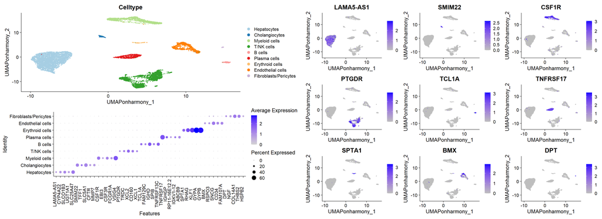

```r
Liver_gg
```

# 5 Marker stability under cluster downsampling

To assess marker robustness in small cell populations, I subjected each annotated cell type to a series of fixed maximum cluster size constraints. To achieve genuine data permutation, at each defined size threshold, I repeatedly downsampled the cells across twenty independent iterations using an array of distinct random seeds. For each replication, I identified marker genes using both the U-method and Wilcoxon differential expression, and quantified marker recovery as the fraction of the top 5 baseline markers from the entire dataset, calculated independently for each respective method, that successfully remained within the top 5 selection under downsampling pressure.

This analysis evaluates how rapidly each method loses marker consistency as cluster size decreases. I also calculated the average runtime of each framework, and measured marker recovery rates both as a combined global summary and individually broken down by specific cellular clusters.

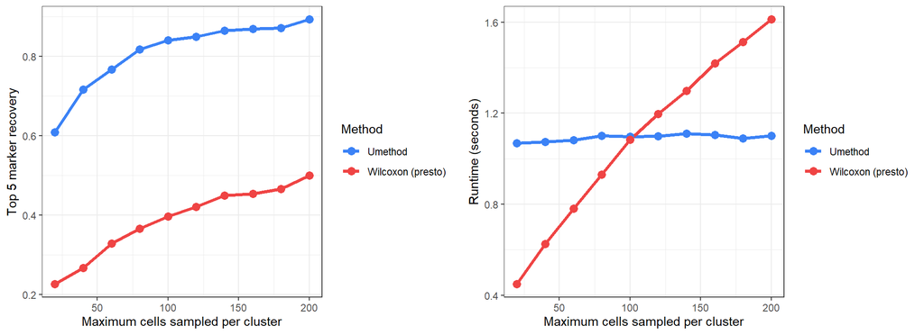

```r
sizes <- c(20,40,60,80,100,120,140,160,180,200)
reps <- 20

MethodColors <- c(
  "Umethod" = "#3B82F6",
  "Wilcoxon (presto)" = "#EF4444"
)

Reference_U_tmp <- FindUniqueMarkers(
  obj = seurat_harmonized,
  group_by = "Celltype",
  n = 5
)$gene_set

Reference_U <- lapply(
  colnames(Reference_U_tmp),
  function(i){Reference_U_tmp[, i]}
)

names(Reference_U) <- colnames(Reference_U_tmp)

Idents(seurat_harmonized) <- "Celltype"

Reference_W <- FindAllMarkers(
  seurat_harmonized,
  assay = "RNA",
  group.by = "Celltype",
  only.pos = TRUE,
  test.use = "wilcox"
)

Reference_W <- Reference_W %>%
  dplyr::filter(
    abs(avg_log2FC) > 2,
    p_val_adj < 0.05,
    pct.1 > 0.2
  ) %>%
  dplyr::group_by(cluster) %>%
  dplyr::slice_max(
    order_by = abs(avg_log2FC),
    n = 5,
    with_ties = FALSE
  ) %>%
  dplyr::summarise(
    genes = list(gene),
    .groups = "drop"
  )

Reference_W <- setNames(
  Reference_W$genes,
  Reference_W$cluster
)

Results <- data.frame()
Runtime <- data.frame()
GeneSelections <- data.frame()

# Bypassing the Seurat subset engine that made my sampling fixed
cell_pools <- lapply(levels(seurat_harmonized$Celltype), function(ct) {
  colnames(seurat_harmonized)[seurat_harmonized$Celltype == ct]
})

names(cell_pools) <- levels(seurat_harmonized$Celltype)

for(size in sizes){

  cat("Running size =", size, "\n")

  for(rep in 1:reps){

    set.seed(5678 + (size * 13) + (rep * 997))

    sampled_cells <- unlist(
      lapply(names(cell_pools), function(ct) {
        pool <- cell_pools[[ct]]
        sample(pool, min(length(pool), size), replace = FALSE)
      }),
      use.names = FALSE
    )

    sub <- seurat_harmonized[, sampled_cells]
    sampled_table <- table(sub$Celltype)

    U.time <- system.time({
      Umarkers <- FindUniqueMarkers(
        obj = sub,
        group_by = "Celltype",
        n = 5
      )$gene_set
    })

    Runtime <- rbind(
      Runtime,
      data.frame(
        Method = "Umethod",
        Size = size,
        Rep = rep,
        Seconds = unname(U.time["elapsed"])
      )
    )

    for(i in colnames(Umarkers)){

      tmpgenes <- as.character(Umarkers[, i])
      overlap <- length(intersect(tmpgenes, Reference_U[[i]])) / 5

      Results <- rbind(
        Results,
        data.frame(
          Method = "Umethod",
          Cluster = i,
          Size = size,
          Actual_cells = as.numeric(sampled_table[i]),
          Rep = rep,
          Overlap = overlap
        )
      )

      GeneSelections <- rbind(
        GeneSelections,
        data.frame(
          Method = "Umethod",
          Cluster = i,
          Size = size,
          Actual_cells = as.numeric(sampled_table[i]),
          Rep = rep,
          Rank = seq_along(tmpgenes),
          Gene = tmpgenes
        )
      )
    }

    W.time <- system.time({
      Wmarkers <- FindAllMarkers(
        sub,
        assay = "RNA",
        group.by = "Celltype",
        only.pos = TRUE,
        test.use = "wilcox"
      )
    })

    Runtime <- rbind(
      Runtime,
      data.frame(
        Method = "Wilcoxon (presto)",
        Size = size,
        Rep = rep,
        Seconds = unname(W.time["elapsed"])
      )
    )

    if(nrow(Wmarkers) > 0){

      Wmarkers_processed <- Wmarkers %>%
        dplyr::filter(
          abs(avg_log2FC) > 2,
          p_val_adj < 0.05,
          pct.1 > 0.2
        ) %>%
        dplyr::group_by(cluster) %>%
        dplyr::slice_max(
          order_by = abs(avg_log2FC),
          n = 5,
          with_ties = FALSE
        ) %>%
        dplyr::summarise(
          genes = list(gene),
          .groups = "drop"
        )

    } else {

      Wmarkers_processed <- data.frame(
        cluster = character(),
        genes = I(list())
      )
    }

    for(i in levels(seurat_harmonized$Celltype)){

      match_idx <- which(Wmarkers_processed$cluster == i)

      if(length(match_idx) > 0 && i %in% names(Reference_W)){

        tmpgenes <- Wmarkers_processed$genes[[match_idx[1]]]
        overlap <- length(intersect(tmpgenes, Reference_W[[i]])) / 5

        GeneSelections <- rbind(
          GeneSelections,
          data.frame(
            Method = "Wilcoxon (presto)",
            Cluster = i,
            Size = size,
            Actual_cells = as.numeric(sampled_table[i]),
            Rep = rep,
            Rank = seq_along(tmpgenes),
            Gene = tmpgenes
          )
        )

      } else {

        overlap <- 0
      }

      Results <- rbind(
        Results,
        data.frame(
          Method = "Wilcoxon (presto)",
          Cluster = i,
          Size = size,
          Actual_cells = as.numeric(sampled_table[i]),
          Rep = rep,
          Overlap = overlap
        )
      )
    }
  }
}

# Keep cell type order fixed

Results$Cluster <- factor(
  Results$Cluster,
  levels = levels(seurat_harmonized$Celltype)
)

GeneSelections$Cluster <- factor(
  GeneSelections$Cluster,
  levels = levels(seurat_harmonized$Celltype)
)

Runtime$Method <- factor(
  Runtime$Method,
  levels = c("Umethod","Wilcoxon (presto)")
)

Results$Method <- factor(
  Results$Method,
  levels = c("Umethod","Wilcoxon (presto)")
)

GeneSelections$Method <- factor(
  GeneSelections$Method,
  levels = c("Umethod","Wilcoxon (presto)")
)

cluster_n <- table(seurat_harmonized$Celltype)

cluster_labels <- setNames(
  paste0(
    names(cluster_n),
    " (n=",
    as.numeric(cluster_n),
    ")"
  ),
  names(cluster_n)
)

# Overall marker recovery

p_overlap <- ggplot(
  Results,
  aes(
    x = Size,
    y = Overlap,
    color = Method,
    group = Method
  )
)+
  stat_summary(
    fun = mean,
    geom = "line",
    linewidth = 1.3
  )+
  stat_summary(
    fun = mean,
    geom = "point",
    size = 3
  )+
  scale_color_manual(values = MethodColors)+
  ylab("Top 5 marker recovery")+
  xlab("Maximum cells sampled per cluster")+
  theme_bw()

# Runtime comparison (Removed log scale transformation)

p_runtime <- ggplot(
  Runtime,
  aes(
    x = Size,
    y = Seconds,
    color = Method,
    group = Method
  )
)+
  stat_summary(
    fun = mean,
    geom = "line",
    linewidth = 1.3
  )+
  stat_summary(
    fun = mean,
    geom = "point",
    size = 3
  )+
  scale_color_manual(values = MethodColors)+
  ylab("Runtime (seconds)")+
  xlab("Maximum cells sampled per cluster")+
  theme_bw()

plot_grid(
  p_overlap,
  p_runtime,
  ncol = 2
)
```

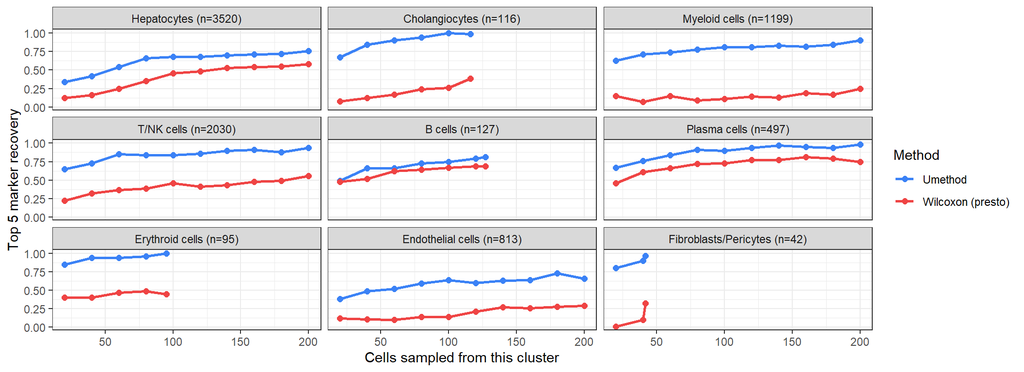

```r
# Marker recovery by cell type

p_cluster <- ggplot(
  Results,
  aes(
    x = Actual_cells,
    y = Overlap,
    color = Method,
    group = Method
  )
)+
  stat_summary(
    fun = mean,
    geom = "line",
    linewidth = 1
  )+
  stat_summary(
    fun = mean,
    geom = "point",
    size = 2
  )+
  scale_color_manual(values = MethodColors)+
  facet_wrap(
    ~Cluster,
    ncol = 3,
    labeller = as_labeller(cluster_labels)
  )+
  ylab("Top 5 marker recovery")+
  xlab("Cells sampled from this cluster")+
  theme_bw()

p_cluster
```

# 6 Stable markers at 20 cells

To better understand the source of the observed stability, I examined the markers that remained detectable under the harshest repeated downsampling in this exercise. Rather than focusing on a single realization of the data, this analysis identifies markers that repeatedly reappear across independent subsamples.

```r
# 1. Expand Reference lists into dataframes for a direct, clean join
ref_u_df <- data.frame(
  Method = "Umethod",
  Cluster = rep(names(Reference_U), each = 5),
  Gene = unlist(Reference_U, use.names = FALSE),
  Is_Reference = TRUE
)

ref_w_df <- data.frame(
  Method = "Wilcoxon (presto)",
  Cluster = rep(names(Reference_W), each = 5),
  Gene = unlist(Reference_W, use.names = FALSE),
  Is_Reference = TRUE
)

reference_markers <- rbind(ref_u_df, ref_w_df)

# 2. Calculate frequencies and strictly match them to the baseline reference
StableGenes20 <- GeneSelections %>%
  dplyr::filter(Size == min(sizes)) %>%
  dplyr::group_by(Method, Cluster, Gene) %>%
  dplyr::summarise(
    Appearance_Count = dplyr::n(),
    Mean_Rank_Within_Top5 = round(mean(Rank), 2),
    .groups = "drop"
  ) %>%
  dplyr::mutate(Selection_Frequency = Appearance_Count / reps) %>%
  dplyr::arrange(Cluster, Method, dplyr::desc(Selection_Frequency), Mean_Rank_Within_Top5)

DT::datatable(StableGenes20[order(StableGenes20$Selection_Frequency,decreasing = T),], options = list(pageLength = 10, autoWidth = TRUE,scrollX = TRUE))
```

|  | Method | Cluster | Gene | Appearance_Count | Mean_Rank_Within_Top5 | Selection_Frequency |
| --- | --- | --- | --- | --- | --- | --- |
| 1 | Umethod | Cholangiocytes | FXYD2 | 20 | 1.55 | 1 |
| 2 | Umethod | Myeloid cells | AIF1 | 20 | 1.85 | 1 |
| 3 | Umethod | Plasma cells | MZB1 | 20 | 1 | 1 |
| 4 | Umethod | Fibroblasts/Pericytes | DCN | 20 | 2.05 | 1 |
| 5 | Umethod | T/NK cells | GZMA | 19 | 1.84 | 0.95 |
| 6 | Umethod | Fibroblasts/Pericytes | MYL9 | 19 | 2.63 | 0.95 |
| 7 | Umethod | Erythroid cells | ALAS2 | 18 | 2.56 | 0.9 |
| 8 | Umethod | Erythroid cells | HBD | 18 | 3.56 | 0.9 |
| 9 | Umethod | T/NK cells | CCL5 | 17 | 2.59 | 0.85 |
| 10 | Umethod | B cells | MS4A1 | 17 | 1.76 | 0.85 |

[output cut: 487 more lines]

# 7 Interpretation

Single-cell datasets represent only a fraction of the cells present within a tissue. Marker robustness under repeated downsampling therefore provides a practical measure of how sensitive a marker is to sampling variation. Markers that remain detectable across subsamples are more likely to reflect stable features of cellular identity than features that depend on a particular realization of the data.

Cell identity is a high-dimensional biological concept, but in practice researchers often rely on a small number of characteristic markers to annotate clusters. For example, a cluster in which MS4A1 are detected in nearly all cells, while remaining largely absent from other clusters, would be readily recognized as a B-cell population, the same goes for MZB1 in plasma cells. Such markers allow different readers to arrive at the same biological interpretation, providing a common starting point for downstream analyses.

Viewed in this context, the U-method is not intended to replace differential expression analysis. Rather, it prioritizes highly polarized markers that appear to remain stable under subsampling and that frequently correspond to canonical lineage markers. These markers can provide a robust first-pass annotation of cellular identity, after which conventional differential expression methods may be used to investigate more subtle or context-specific biological differences.

The U-method demonstrated high computational efficiency, performing comparably to the accelerated Wilcoxon framework (presto) and pacing ahead of rank-sum calculations as sample size scaled higher. This efficiency suggest that the underlying framework is well-suited for integration into high-throughput machine learning workflows. Furthermore, by demonstrating that expression probability maps so strongly to stable cell identity, these findings highlight a robust alternative parameter space for developing future cell-annotation algorithms

Together, these results suggest that expression polarization provides a stable and practical basis for the initial annotation of cell populations, particularly when cell numbers are limited.

The U-method: Leveraging expression probability for robust biological marker detection https://www.biorxiv.org/content/10.64898/2026.03.31.715470v1